# Hw1-Moneyball

Santosh Manjrekar

September 23, 2019

## Introduction

Explore, analyze and model a data set containing approximately 2200 records. Each record represents a professional baseball team from the years 1871 to 2006 inclusive. Each record has the performance of the team for the given year, with all of the statistics adjusted to match the performance ofa 162 game season.

Your objective is to build a multiple linear regression model on the training data to predict the number of wins for the team.

## Data Exploration

Note that each record has the performance of the team for the given year, with all of the statistics adjusted to match the performance of a 162 game season. The following Table 1 - Descriptive Statistics provides the detailed descriptive statistics regarding our variable of interest - Number of Wins and our possible explanatory variables.

We noted that several variables were missing a nontrivial amount of observations and these variables are Strikeouts by batters, Stolen Bases, Caught stealing, Batters hit by pitch (get a free base), Strikeouts by pitcher, and Double plays. So we will need to address the missing values for further analysis.

```r
data_dictionary <- read.xlsx("Data Dictionary.xlsx", sheetIndex = 1)
#file.remove(dir(getwd(), pattern = "Data Dictionary", full.names = TRUE))
```

### Explore the data

Summary and discriptive statistics Descriptive statistics is used here to summarize the data to gather insights into the information contained in the dataset. The descriptive statistics below shows the the mean, mode, standard deviation, skew,lowest and highest values of each variable in the dataset.

```r
#summary(df)
descriptive
```

```
## Table 1 : Descriptive Statistics
##
##  16  Variables      2276  Observations
## ---------------------------------------------------------------------------
## Number of wins
##        n  missing distinct     Mean   Median       SD     Skew Gmd freq
##     2276        0      108       81       82     15.8     -0.4       17
## .90 freq
##      100
##
## lowest :   0  12  14  17  21, highest: 128 129 134 135 146
## ---------------------------------------------------------------------------
## Base Hits by batters (1B,2B,3B,HR)
##        n  missing distinct     Mean   Median       SD     Skew Gmd freq
##     2276        0      569     1469     1454    144.6      1.6      150
## .90 freq
##     1636
##
## lowest :  891  992 1009 1116 1122, highest: 2333 2343 2372 2496 2554
## ---------------------------------------------------------------------------
## Doubles by batters (2B)
##        n  missing distinct     Mean   Median       SD     Skew Gmd freq
##     2276        0      240      241      238     46.8      0.2       53
## .90 freq
##      303
##
## lowest :  69 112 113 118 123, highest: 382 392 393 403 458
## ---------------------------------------------------------------------------
## Triples by batters (3B)
##        n  missing distinct     Mean   Median       SD     Skew Gmd freq
##     2276        0      144       55       47     27.9      1.1       30
## .90 freq
##       96
##
## lowest :   0   8   9  11  12, highest: 166 190 197 200 223
## ---------------------------------------------------------------------------
## Homeruns by batters (4B)
##        n  missing distinct     Mean   Median       SD     Skew Gmd freq
##     2276        0      243      100      102     60.5      0.2       69
## .90 freq
```

[output cut: 83 more lines]

```
##        n  missing distinct     Mean   Median       SD     Skew Gmd freq
##     2276        0      549      246      159    227.8        3      190
## .90 freq
##      542
##
## lowest :   65   66   68   72   74, highest: 1567 1728 1740 1890 1898
## ---------------------------------------------------------------------------
## Double Plays
##        n  missing distinct     Mean   Median       SD     Skew Gmd freq
##     1990      286      144      146      149     26.2     -0.4       29
## .90 freq
##      178
##
## lowest :  52  64  68  71  72, highest: 215 218 219 225 228
## ---------------------------------------------------------------------------
```

## Imputing Missing Values

In order to address the missing values in our variables we used a nonparametric imputation method (Random Forest) to impute missing values. Several variables have a significant amount of skew, which include the number of base hits by batters and the number of walks allowed. Correspondingly, these two variables had a skew of 1.57 and 6.74 respectively. Therefore, we chose a nonparametric method due to several variables having significant skew and having a non-normal distribution.

## Correlation Matrix

After competing the imputation, we can implement a correlation matrix to better understand the correlation between variables in the data set. The below matrix is the results and as expected, Number of Wins appears to be most correlated to Base Hits by batters (1B,2B,3B,HR).

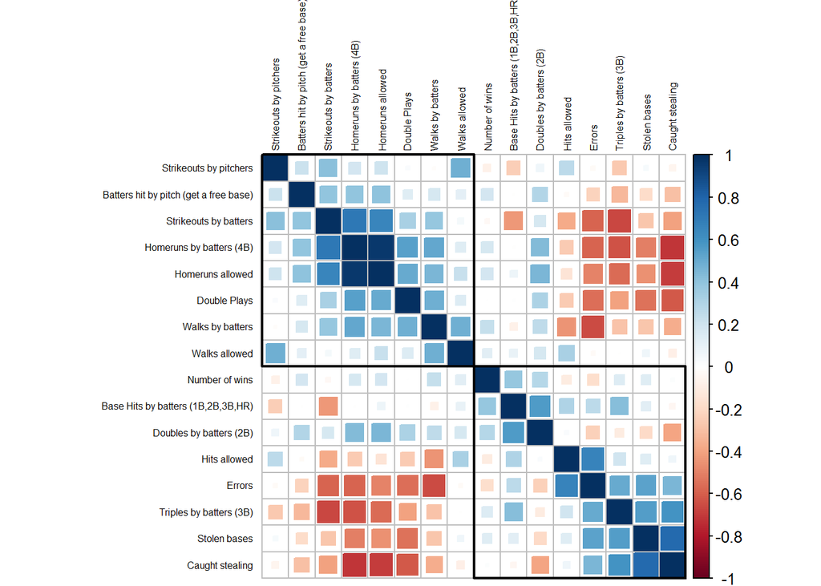

Correlation Plot of Training Data Set with imputed values

# Data Preparation

First, we chose to eliminate two variables that had a significant number of missing data points. These variables were Batters hit by pitch (get a free base) and Caught stealing, which were missing 91.6% and 33.9% respectively.

Additionally, we reduced the data set to the following variables for modeling simplicity. Base Hits by batters (1B,2B,3B,HR), Strikeouts by batters, Walks by batters, Double plays, Walks allowed, Triples by batters (3B), and Hits allowed.

Missing values in the remaining columns had been imputed using the random forest method as previous discussed.

# Models Built

All models included Base Hits by batters (1B,2B,3B,HR) which is the most correlated variable to Number of Wins as indicated in the correlation matrix. This is expected as Base Hits are necessary to win any game.

## Model 1

```r
lmfit1 <- lm(data = imputed_df,
           sqrt(`Number of wins`) ~ `Base Hits by batters (1B,2B,3B,HR)` +
                                    `Walks by batters` +
                                    `Strikeouts by batters`)

summary(lmfit1)
```

```
##
## Call:
## lm(formula = sqrt(`Number of wins`) ~ `Base Hits by batters (1B,2B,3B,HR)` +
##     `Walks by batters` + `Strikeouts by batters`, data = imputed_df)
##
## Residuals:
##     Min      1Q  Median      3Q     Max
## -6.0625 -0.4813  0.0565  0.5315  2.6158
##
## Coefficients:
##                                       Estimate Std. Error t value Pr(>|t|)
## (Intercept)                          3.560e+00  2.274e-01  15.657  < 2e-16
## `Base Hits by batters (1B,2B,3B,HR)` 2.809e-03  1.327e-04  21.162  < 2e-16
## `Walks by batters`                   1.956e-03  1.521e-04  12.860  < 2e-16
## `Strikeouts by batters`              3.719e-04  8.493e-05   4.379 1.24e-05
##
## (Intercept)                          ***
## `Base Hits by batters (1B,2B,3B,HR)` ***
## `Walks by batters`                   ***
## `Strikeouts by batters`              ***
## ---
## Signif. codes:  0 '***' 0.001 '**' 0.01 '*' 0.05 '.' 0.1 ' ' 1
##
## Residual standard error: 0.8167 on 2272 degrees of freedom
## Multiple R-squared:  0.2317, Adjusted R-squared:  0.2307
## F-statistic: 228.4 on 3 and 2272 DF,  p-value: < 2.2e-16
```

The below plot of our fitted values against our residuals indicate that there is Heteroskadistity and showing uneven variation.

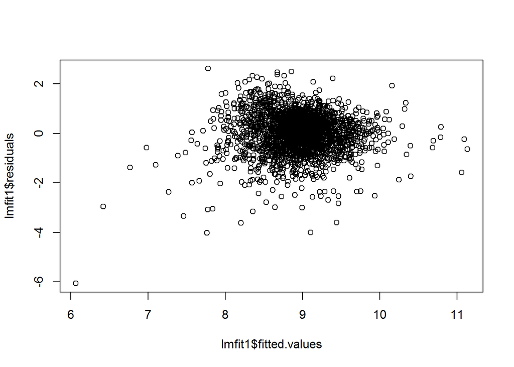

## Model 2

We added Walks allowed and Double Plays. The reason being that Walks allowed is possibly an indicator of poor pitching and Double Plays is an indicator of a competent infield team that prevents other teams from scoring.

```r
lmfit2 <- lm(data = imputed_df,
           sqrt(`Number of wins`) ~ `Base Hits by batters (1B,2B,3B,HR)` +
                                    `Walks allowed` +
                                    `Double Plays`)
summary(lmfit2)
```

```
##
## Call:
## lm(formula = sqrt(`Number of wins`) ~ `Base Hits by batters (1B,2B,3B,HR)` +
##     `Walks allowed` + `Double Plays`, data = imputed_df)
##
## Residuals:
##     Min      1Q  Median      3Q     Max
## -7.2748 -0.4534  0.0890  0.5679  2.3888
##
## Coefficients:
##                                       Estimate Std. Error t value Pr(>|t|)
## (Intercept)                          5.1401159  0.2084345  24.661  < 2e-16
## `Base Hits by batters (1B,2B,3B,HR)` 0.0023580  0.0001252  18.833  < 2e-16
## `Walks allowed`                      0.0005007  0.0001100   4.551 5.61e-06
## `Double Plays`                       0.0004108  0.0006725   0.611    0.541
##
## (Intercept)                          ***
## `Base Hits by batters (1B,2B,3B,HR)` ***
## `Walks allowed`                      ***
## `Double Plays`
## ---
## Signif. codes:  0 '***' 0.001 '**' 0.01 '*' 0.05 '.' 0.1 ' ' 1
##
## Residual standard error: 0.8596 on 2272 degrees of freedom
## Multiple R-squared:  0.1488, Adjusted R-squared:  0.1476
## F-statistic: 132.4 on 3 and 2272 DF,  p-value: < 2.2e-16
```

The below plot of our fitted values against our residuals indicate that there is Heteroskadistity and showing uneven variation.

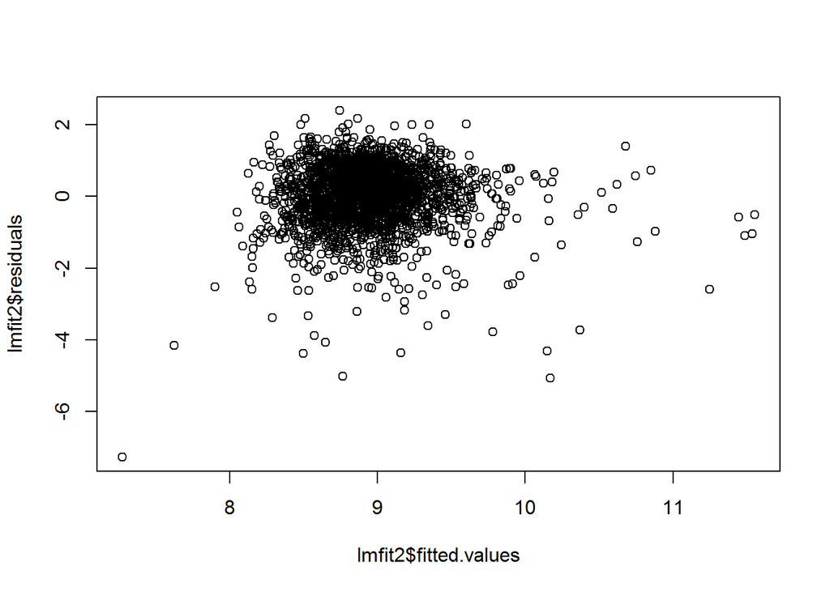

## Model 3

We included Triples by batters and Hits allowed. Additonally, as expected, the Hits allowed has a negative relationship to wins because hits allowed indicates the other team getting a hit and possibly scoring a point.

```r
lmfit3 <- lm(data = imputed_df,
            `Number of wins` ~ `Base Hits by batters (1B,2B,3B,HR)` +
                               `Triples by batters (3B)` +
                               `Hits allowed`)

summary(lmfit3)
```

```
##
## Call:
## lm(formula = `Number of wins` ~ `Base Hits by batters (1B,2B,3B,HR)` +
##     `Triples by batters (3B)` + `Hits allowed`, data = imputed_df)
##
## Residuals:
##     Min      1Q  Median      3Q     Max
## -57.222  -9.000   0.554   9.375  81.180
##
## Coefficients:
##                                        Estimate Std. Error t value
## (Intercept)                          11.0979200  3.1401404   3.534
## `Base Hits by batters (1B,2B,3B,HR)`  0.0510123  0.0023221  21.968
## `Triples by batters (3B)`            -0.0050485  0.0116776  -0.432
## `Hits allowed`                       -0.0027984  0.0002199 -12.723
##                                      Pr(>|t|)
## (Intercept)                          0.000417 ***
## `Base Hits by batters (1B,2B,3B,HR)`  < 2e-16 ***
## `Triples by batters (3B)`            0.665547
## `Hits allowed`                        < 2e-16 ***
## ---
## Signif. codes:  0 '***' 0.001 '**' 0.01 '*' 0.05 '.' 0.1 ' ' 1
##
## Residual standard error: 14.03 on 2272 degrees of freedom
## Multiple R-squared:  0.2082, Adjusted R-squared:  0.2072
## F-statistic: 199.2 on 3 and 2272 DF,  p-value: < 2.2e-16
```

The below plot of our fitted values against our residuals indicate that there is Heteroskadistity and showing uneven variation.

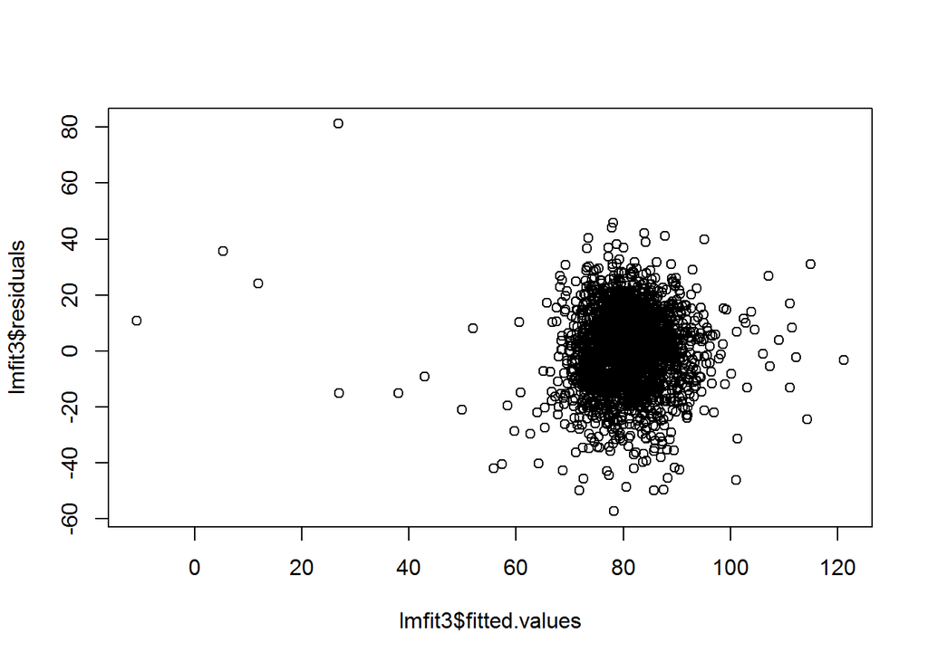

## Selected Model

Our residuals in each model indcated Heteroskadistity and showed uneven variation. Therefore, we chose the model with the highest Adjusted R-squared which was Model 1. The Adjusted R-squared of each model is provided in the below table.

[output not shown]

Therefore, our final model with the greatest Adjusted R-squared is:

$$\begin{aligned}
\sqrt{\textnormal{Number~of~wins}}~=~&\textnormal{0.002809 * Base Hits by batters (1B,2B,3B,HR)} \\
&\textnormal{+ 0.001956 * Walks by batters} \\
&\textnormal{+ 0.0003719 * Strikeouts by batters} \\
&\textnormal{+ 3.559588}
\end{aligned}$$

Additionally, we are 95% confident that our regression values lie between the two values from the output in the below table.

|  | 2.5 % | 97.5 % |
| --- | --- | --- |
| (Intercept) | 3.1137475 | 4.0054293 |
| `Base Hits by batters (1B,2B,3B,HR)` | 0.0025488 | 0.0030695 |
| `Walks by batters` | 0.0016578 | 0.0022544 |
| `Strikeouts by batters` | 0.0002054 | 0.0005385 |

# Prediction on Evaluation Data

Using our best performing model we used the predict R function and excluded evaluation data with missing values. The below table is our prediction results for the evaluation data set.

| Identification Variable (do not use) | predictions |
| --- | --- |
| 9 | 67 |
| 10 | 69 |
| 14 | 77 |
| 47 | 84 |
| 60 | 63 |
| 63 | 66 |
| 74 | 78 |
| 83 | 70 |
| 98 | 68 |
| 120 | 73 |
| 123 | 76 |
| 135 | 79 |
| 138 | 77 |
| 140 | 79 |
| 151 | 76 |
| 153 | 75 |
| 171 | 72 |
| 184 | 83 |
| 213 | 91 |
| 217 | 85 |
| 226 | 89 |
| 230 | 83 |
| 241 | 76 |
| 291 | 80 |
| 294 | 84 |
| 300 | 62 |
| 348 | 74 |
| 350 | 87 |
| 357 | 78 |
| 367 | 93 |

[output cut: 211 more lines]